# MA641 Project Scratch

Brianna Cirillo

### Libraries

```r
# Load necessary libraries
library(forecast)
library(tseries)
library(TSA)
library(tidyverse)
```

## FRED Monthly Retail Sales

### Load & Inspect the Data

```r
# Load in the data
data <- read.csv("~/Documents/GitHub/MA-641-Course-Project/FRED_monthly_retail_sales.csv",header=T)

# Convert the date column to Date type
data$DATE <- as.Date(data$DATE, format="%Y-%m-%d")

# Inspect the data
head(data)
```

|  | DATE | RSXFSN |
| --- | --- | --- |
| 1 | 2018-01-01 | 389624 |
| 2 | 2018-02-01 | 380456 |
| 3 | 2018-03-01 | 444725 |
| 4 | 2018-04-01 | 420206 |
| 5 | 2018-05-01 | 464422 |
| 6 | 2018-06-01 | 443762 |

```r
summary(data)
```

```
##       DATE                RSXFSN
##  Min.   :2018-01-01   Min.   :376261
##  1st Qu.:2019-08-01   1st Qu.:455157
##  Median :2021-03-01   Median :518796
##  Mean   :2021-03-01   Mean   :518801
##  3rd Qu.:2022-10-01   3rd Qu.:592577
##  Max.   :2024-05-01   Max.   :668957
```

- The dataset spans from January 2018 to May 2024, covering over six years of monthly data.
- The retail sales values range from 376,261 to 668,957.
- The median and mean values are close to each other (around 518,800), suggesting a symmetric distribution.
- The interquartile range (IQR) is the difference between the 3rd and 1st quartiles (592,577 - 455,157 = 137,420), which measures the spread of the middle 50% of the data.
- There is a noticeable increase in retail sales over time, as indicated by the higher values in the upper quartiles compared to the lower quartiles.

### Create a Time Series Object

```r
# Create a time series object
ts_data <- ts(data$RSXFSN, start=c(2018, 12), frequency=12)
```

### Descriptive Analysis

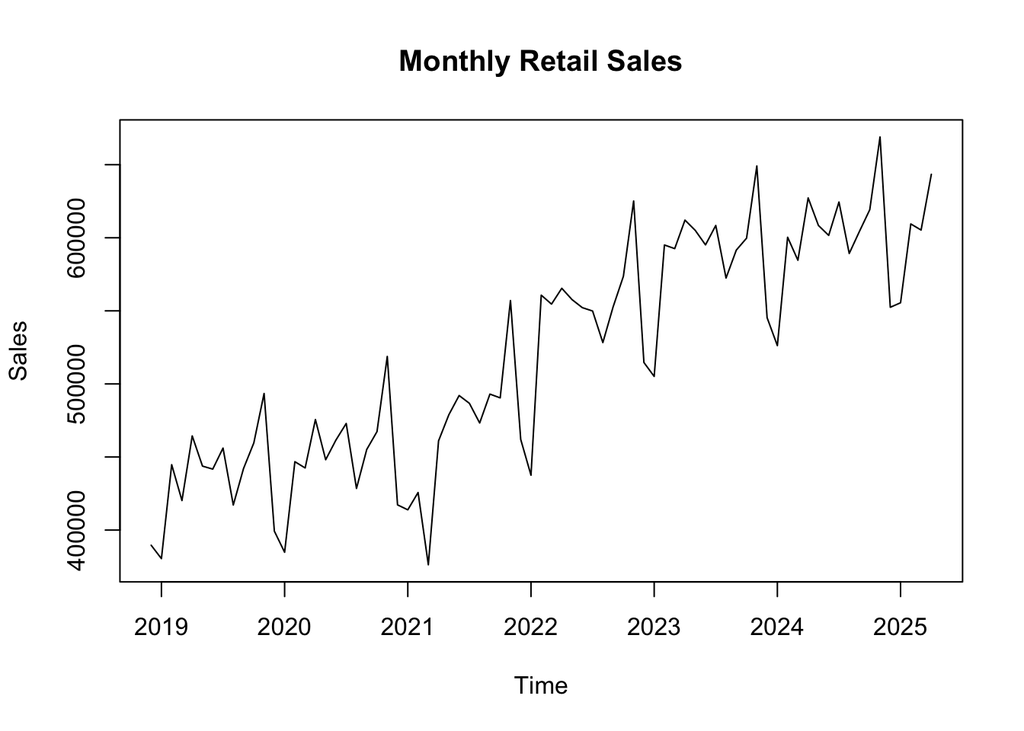

```r
# Descriptive Analysis
plot(ts_data, main="Monthly Retail Sales", ylab="Sales", xlab="Time")
```

```r
summary(ts_data)
```

```
##    Min. 1st Qu.  Median    Mean 3rd Qu.    Max.
##  376261  455157  518796  518801  592577  668957
```

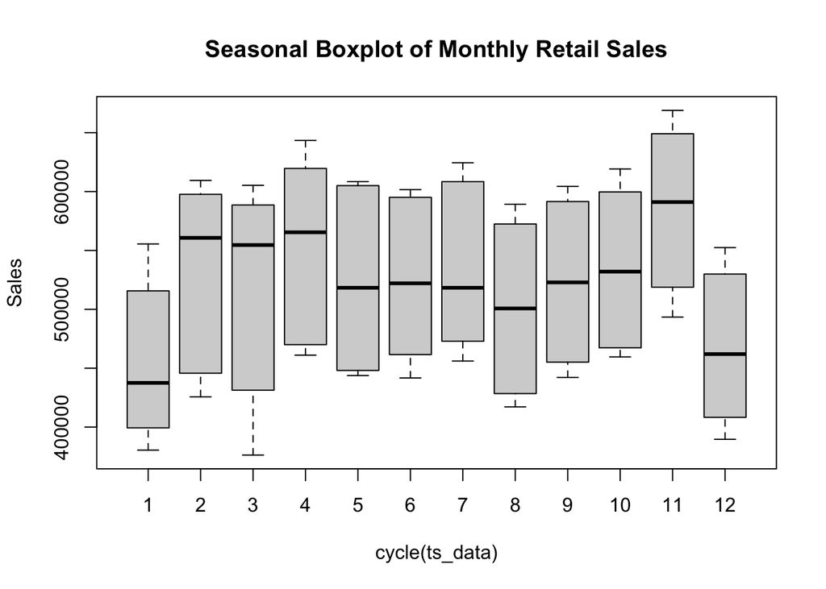

```r
boxplot(ts_data ~ cycle(ts_data), main="Seasonal Boxplot of Monthly Retail Sales", ylab="Sales")
```

Time Series Plot:

- There is an upward trend in retail sales over the period from 2018 to 2024. This indicates that retail sales have been generally increasing over time.
- There are repeating patterns within each year, indicative of seasonality.
- The amplitude of fluctuations increases over time, indicating growing volatility in sales.

Seasonal Boxplots:

- There is evident seasonal variation in monthly retail sales. For example, January (month 1) tends to have lower sales, while November (month 11) shows higher sales.
- The interquartile range (IQR) and the median values vary significantly across months, indicating changes in sales patterns throughout the year.
- The presence of outliers can indicate unusual sales activity in certain months.
- November has the highest median sales, indicating consistently higher sales in this month.